# Spatial Regression for Florida

M. Pierson

# Data

Run simple OLS to test for relationships:

```
Call:
lm(formula = equation, data = fl_pov)

Residuals:
     Min       1Q   Median       3Q      Max
-22.0652  -1.8946   0.1788   3.3646   9.1837

Coefficients:
                Estimate Std. Error t value Pr(>|t|)
(Intercept)    -54.21668   21.70961  -2.497   0.0156 *
rural           -8.33918   13.18149  -0.633   0.5296
urban           -1.17878    2.54394  -0.463   0.6450
lnag             1.58522    1.17827   1.345   0.1841
lnretail         3.86337    4.58941   0.842   0.4036
lnlesshs         7.90035    4.07665   1.938   0.0579 .
lnunemployment   7.78955    6.04811   1.288   0.2033
lnsinglemom      1.15335    3.89962   0.296   0.7685
lnblack         -0.03640    1.78382  -0.020   0.9838
lnhispanic       0.06891    1.14254   0.060   0.9521
lnincome_ratio  12.04320    7.02788   1.714   0.0923 .
lnteenbirth      2.19018    1.99885   1.096   0.2781
lnunmarried      1.07342    3.12779   0.343   0.7328
---
Signif. codes:  0 ‘***’ 0.001 ‘**’ 0.01 ‘*’ 0.05 ‘.’ 0.1 ‘ ’ 1

Residual standard error: 5.86 on 54 degrees of freedom
Multiple R-squared:  0.5732,    Adjusted R-squared:  0.4784
F-statistic: 6.044 on 12 and 54 DF,  p-value: 0.000001482
```

There are only two minor significant factors.

## SRA, Contiguity

Morans Correlation, and LaGrange Multiplier Tests: Examine the residuals of the OLS regression using the spatial relationship matrix. The null hypothesis (HO) is “no spatial correlation in the residuals”.

```
    Global Moran I for regression residuals

data:
model: lm(formula = equation, data = fl_pov)
weights: cont.neighb

Moran I statistic standard deviate = 2.1457, p-value = 0.01595
alternative hypothesis: greater
sample estimates:
Observed Moran I      Expectation         Variance
     0.129016499     -0.039990714      0.006203894
```

There is a significant p-value of 0.015. Therefore, we reject the HO due to detection of spatial dependency in our data. This suggests we should use a spatial model.

Alternatively, use LaGrange Test: reports the estimates of simple LM tests for error dependence (LMerr), for a missing spatially lagged dependent variable (LMlag), for robust variants of these tests (RLMerr to test for error dependence in the possible presence of a missing lagged dependent variable and RLMlag the other way round), and a portmanteau test (SARMA, in fact LMerr + RLMlag). We can run all of these at once.

```
    Lagrange multiplier diagnostics for spatial dependence

data:
model: lm(formula = equation, data = fl_pov)
weights: cont.neighb

LMerr = 2.3413, df = 1, p-value = 0.126


    Lagrange multiplier diagnostics for spatial dependence

data:
model: lm(formula = equation, data = fl_pov)
weights: cont.neighb

LMlag = 1.8456, df = 1, p-value = 0.1743


    Lagrange multiplier diagnostics for spatial dependence

data:
model: lm(formula = equation, data = fl_pov)
weights: cont.neighb

RLMerr = 0.53555, df = 1, p-value = 0.4643


    Lagrange multiplier diagnostics for spatial dependence

data:
model: lm(formula = equation, data = fl_pov)
weights: cont.neighb

RLMlag = 0.03986, df = 1, p-value = 0.8418


    Lagrange multiplier diagnostics for spatial dependence

data:
model: lm(formula = equation, data = fl_pov)
weights: cont.neighb

SARMA = 2.3811, df = 2, p-value = 0.3041
```

```
Call:spatialreg::errorsarlm(formula = equation, data = fl_pov, listw = cont.neighb)

Residuals:
      Min        1Q    Median        3Q       Max
-20.77749  -1.93697  -0.11079   2.05175   8.90042

Type: error
Coefficients: (asymptotic standard errors)
                Estimate Std. Error z value Pr(>|z|)
(Intercept)    -52.43735   18.15200 -2.8888 0.003867
rural           -5.84303   11.17991 -0.5226 0.601227
urban            0.26988    2.08166  0.1296 0.896847
lnag             1.46871    1.04127  1.4105 0.158392
lnretail         1.35462    3.70332  0.3658 0.714525
lnlesshs         8.56713    3.53700  2.4221 0.015429
lnunemployment   7.03395    5.44048  1.2929 0.196048
lnsinglemom      0.89115    3.39032  0.2629 0.792665
lnblack          1.06964    1.52922  0.6995 0.484258
lnhispanic       0.65874    1.33211  0.4945 0.620946
lnincome_ratio  12.04688    6.02450  1.9996 0.045538
lnteenbirth      1.73647    1.64832  1.0535 0.292122
lnunmarried      1.51627    2.61358  0.5801 0.561814

Lambda: 0.4243, LR test value: 4.2973, p-value: 0.038173
Asymptotic standard error: 0.13747
    z-value: 3.0865, p-value: 0.0020253
Wald statistic: 9.5265, p-value: 0.0020253

Log likelihood: -204.1582 for error model
ML residual variance (sigma squared): 24.78, (sigma: 4.9779)
Nagelkerke pseudo-R-squared: 0.59974
Number of observations: 67
Number of parameters estimated: 15
AIC: 438.32, (AIC for lm: 440.61)
```

In the summary there are two (2) significant log variables including: less than high school education, and income ratio.

To test the validity of the error model run a Spatial Hausman Test to see if the results of the analysis verifies the use of the model:

```
    Spatial Hausman test (asymptotic)

data:  NULL
Hausman test = 12.738, df = 13, p-value = 0.4682
```

Based on the p-value of 0.4682 we wouldn’t reject the HO that the estimation method should yield coefficients appropriate for a spatial error model. If the p-value had been significant, we would have concluded that the use of OLS or a standard error model may not be appropriate for this set of variables.

Alternatively, we could have a nested model to explore the likelihood of which model would be appropriate for our data. Because we already know that an error model is the most appropriate analysis we will use the Spatial Durbin Error Model:

```
Call:spatialreg::errorsarlm(formula = equation, data = fl_pov, listw = cont.neighb,
    etype = "emixed")

Residuals:
       Min         1Q     Median         3Q        Max
-17.990569  -2.652511  -0.022909   2.551410   9.278716

Type: error
Coefficients: (asymptotic standard errors)
                    Estimate Std. Error z value Pr(>|z|)
(Intercept)        -91.54813   50.61253 -1.8088  0.07048
rural               -8.84181   12.03494 -0.7347  0.46254
urban               -1.14794    2.33126 -0.4924  0.62243
lnag                 2.11016    1.04372  2.0218  0.04320
lnretail             4.01444    3.96637  1.0121  0.31148
lnlesshs             7.18386    3.81431  1.8834  0.05965
lnunemployment       0.92938    6.22779  0.1492  0.88137
lnsinglemom          1.84134    3.55064  0.5186  0.60404
lnblack              0.99254    1.65095  0.6012  0.54771
lnhispanic           0.53534    1.94425  0.2753  0.78305
lnincome_ratio      13.13820    5.95178  2.2074  0.02728
lnteenbirth          2.04727    1.84589  1.1091  0.26739
lnunmarried          1.89108    2.92662  0.6462  0.51817
lag.rural            9.67395   24.56515  0.3938  0.69372
lag.urban           -7.64626    5.15739 -1.4826  0.13819
lag.lnag             0.92399    2.28841  0.4038  0.68638
lag.lnretail        17.59903    9.67760  1.8185  0.06898
lag.lnlesshs        -7.28730    8.70658 -0.8370  0.40260
lag.lnunemployment   0.80544   13.34589  0.0604  0.95188
lag.lnsinglemom      2.36940    8.51112  0.2784  0.78071
lag.lnblack         -5.46724    3.70275 -1.4765  0.13980
lag.lnhispanic      -2.50683    2.24386 -1.1172  0.26391
lag.lnincome_ratio   6.22437   13.10190  0.4751  0.63473
lag.lnteenbirth      2.14898    3.73954  0.5747  0.56552
lag.lnunmarried      4.94671    5.96280  0.8296  0.40677

Lambda: 0.1079, LR test value: 0.16719, p-value: 0.68262
Asymptotic standard error: 0.1703
    z-value: 0.63358, p-value: 0.52635
Wald statistic: 0.40142, p-value: 0.52635

Log likelihood: -196.5027 for error model
ML residual variance (sigma squared): 20.598, (sigma: 4.5385)
Nagelkerke pseudo-R-squared: 0.68151
Number of observations: 67
Number of parameters estimated: 27
AIC: 447.01, (AIC for lm: 445.17)
```

We could also run the global Spatial Durbin Model summary using summary(sdm) however, using a model-driven approach we understand that overall a global model is not appropriate for our data. Meaning, for example, that unemployment in one county could affect poverty in a neighboring county, but it is unlikely to have an impact on a county across the state or every county within the state. So keeping that in mind we will move on using only the Spatial Durbin Error Model. Examining the impacts matrix as we have before we can determine if the Spatial Durbin Error Model is the most appropriate model for our data or if we should restrict the model to a spatial error, SLX, or OLS model.

[output not shown]

Based on the impacts analysis, we can see not many of the impacts are significant, so we might consider limiting the model to either the spatial error, SLX, or OLS models. We should see similar results in our likelihood ration test. This will help us test the HO that we should restrict the model to a more simple model. The first step is to determine if we should restrict the model from a Spatial Durbin Error model to a spatial error mode.

```
    Likelihood ratio for spatial linear models

data:
Likelihood ratio = 15.311, df = 12, p-value = 0.2249
sample estimates:
      Log likelihood of sd.err Log likelihood of sp.err.model
                     -196.5027                      -204.1582
```

Our results are saying that, with a high p-value of 0.2249, we should not reject the null hypothesis. Meaning that we should restrict the model to a spatial error model.

## K nearest neighbors:

Distance lag model:

Summary for the K1 mod:

```
Call:lagsarlm(formula = equation, data = fl_pov, listw = all.dist.neighb.k1)

Residuals:
       Min         1Q     Median         3Q        Max
-22.006390  -1.734339   0.055053   3.126887   9.581461

Type: lag
Coefficients: (asymptotic standard errors)
                 Estimate Std. Error z value Pr(>|z|)
(Intercept)    -59.166669  19.705894 -3.0025 0.002678
rural           -7.778834  11.737668 -0.6627 0.507507
urban           -0.828064   2.268421 -0.3650 0.715082
lnag             1.429608   1.062865  1.3451 0.178609
lnretail         3.613757   4.087382  0.8841 0.376629
lnlesshs         8.067315   3.631998  2.2212 0.026339
lnunemployment   7.756899   5.385970  1.4402 0.149810
lnsinglemom      1.526450   3.494705  0.4368 0.662264
lnblack          0.034086   1.589669  0.0214 0.982893
lnhispanic       0.058121   1.023002  0.0568 0.954693
lnincome_ratio  12.462031   6.258683  1.9912 0.046463
lnteenbirth      2.184297   1.780018  1.2271 0.219777
lnunmarried      1.209844   2.785218  0.4344 0.664012

Rho: 0.11376, LR test value: 0.81335, p-value: 0.36713
Asymptotic standard error: 0.10833
    z-value: 1.0501, p-value: 0.29369
Wald statistic: 1.1027, p-value: 0.29369

Log likelihood: -205.9001 for lag model
ML residual variance (sigma squared): 27.226, (sigma: 5.2178)
Nagelkerke pseudo-R-squared: 0.57838
Number of observations: 67
Number of parameters estimated: 15
AIC: 441.8, (AIC for lm: 440.61)
LM test for residual autocorrelation
test value: 1.6821, p-value: 0.19464
```

Summary for the K3 mod:

```
Call:lagsarlm(formula = equation, data = fl_pov, listw = all.dist.neighb.k3)

Residuals:
       Min         1Q     Median         3Q        Max
-22.072828  -1.995349   0.060676   3.334383   9.204784

Type: lag
Coefficients: (asymptotic standard errors)
                 Estimate Std. Error z value Pr(>|z|)
(Intercept)    -48.308252  20.693770 -2.3344  0.01957
rural           -8.722358  11.802975 -0.7390  0.45991
urban           -1.273600   2.280717 -0.5584  0.57656
lnag             1.631120   1.064228  1.5327  0.12535
lnretail         3.865683   4.109053  0.9408  0.34682
lnlesshs         7.883692   3.652546  2.1584  0.03090
lnunemployment   7.892518   5.430085  1.4535  0.14609
lnsinglemom      1.106501   3.498785  0.3163  0.75181
lnblack         -0.050478   1.598340 -0.0316  0.97481
lnhispanic      -0.017319   1.022862 -0.0169  0.98649
lnincome_ratio  11.301115   6.292829  1.7959  0.07251
lnteenbirth      2.130212   1.793346  1.1878  0.23490
lnunmarried      0.878776   2.802028  0.3136  0.75381

Rho: -0.13851, LR test value: 0.26031, p-value: 0.60991
Asymptotic standard error: 0.22499
    z-value: -0.6156, p-value: 0.53816
Wald statistic: 0.37897, p-value: 0.53816

Log likelihood: -206.1767 for lag model
ML residual variance (sigma squared): 27.521, (sigma: 5.246)
Nagelkerke pseudo-R-squared: 0.57488
Number of observations: 67
Number of parameters estimated: 15
AIC: 442.35, (AIC for lm: 440.61)
LM test for residual autocorrelation
test value: 1.3807, p-value: 0.23998
```

Summary for the K5 mod:

```
Call:lagsarlm(formula = equation, data = fl_pov, listw = all.dist.neighb.k5)

Residuals:
       Min         1Q     Median         3Q        Max
-22.290912  -2.167334   0.041397   3.064633   8.839730

Type: lag
Coefficients: (asymptotic standard errors)
                 Estimate Std. Error z value Pr(>|z|)
(Intercept)    -36.476371  21.963286 -1.6608  0.09676
rural           -8.549403  11.657135 -0.7334  0.46331
urban           -1.131157   2.253101 -0.5020  0.61564
lnag             1.664605   1.046171  1.5911  0.11158
lnretail         3.415712   4.059267  0.8415  0.40009
lnlesshs         7.044814   3.610943  1.9510  0.05106
lnunemployment   8.336081   5.376073  1.5506  0.12100
lnsinglemom      1.495491   3.448615  0.4336  0.66454
lnblack          0.086933   1.582392  0.0549  0.95619
lnhispanic      -0.133608   1.010430 -0.1322  0.89480
lnincome_ratio  11.222350   6.236603  1.7994  0.07195
lnteenbirth      2.033016   1.768154  1.1498  0.25023
lnunmarried      0.768193   2.768156  0.2775  0.78139

Rho: -0.49601, LR test value: 1.2444, p-value: 0.26463
Asymptotic standard error: 0.37303
    z-value: -1.3297, p-value: 0.18362
Wald statistic: 1.768, p-value: 0.18362

Log likelihood: -205.6846 for lag model
ML residual variance (sigma squared): 26.854, (sigma: 5.1821)
Nagelkerke pseudo-R-squared: 0.58108
Number of observations: 67
Number of parameters estimated: 15
AIC: 441.37, (AIC for lm: 440.61)
LM test for residual autocorrelation
test value: 8.2457, p-value: 0.0040849
```

Calculate a distance error model for each k-distance value:

Summary for the K=1 err model:

```
Call:errorsarlm(formula = equation, data = fl_pov, listw = all.dist.neighb.k1)

Residuals:
      Min        1Q    Median        3Q       Max
-21.17521  -1.90278   0.19994   2.30052   8.60652

Type: error
Coefficients: (asymptotic standard errors)
                Estimate Std. Error z value Pr(>|z|)
(Intercept)    -52.68624   17.97929 -2.9304 0.003385
rural           -5.88448   11.36534 -0.5178 0.604628
urban           -0.09558    2.15023 -0.0445 0.964545
lnag             1.80681    1.11058  1.6269 0.103759
lnretail         1.57171    3.87622  0.4055 0.685128
lnlesshs         7.51871    3.58603  2.0967 0.036023
lnunemployment   7.62722    5.45733  1.3976 0.162230
lnsinglemom      0.78974    3.42618  0.2305 0.817702
lnblack          0.93381    1.54475  0.6045 0.545507
lnhispanic       0.63119    1.24930  0.5052 0.613393
lnincome_ratio  13.20855    6.05722  2.1806 0.029211
lnteenbirth      1.84822    1.70096  1.0866 0.277223
lnunmarried      1.49817    2.64335  0.5668 0.570872

Lambda: 0.31268, LR test value: 2.8753, p-value: 0.08995
Asymptotic standard error: 0.12916
    z-value: 2.4209, p-value: 0.01548
Wald statistic: 5.8609, p-value: 0.01548

Log likelihood: -204.8692 for error model
ML residual variance (sigma squared): 25.634, (sigma: 5.063)
Nagelkerke pseudo-R-squared: 0.59115
Number of observations: 67
Number of parameters estimated: 15
AIC: 439.74, (AIC for lm: 440.61)
```

Summary for the K=3 err model:

```
Call:errorsarlm(formula = equation, data = fl_pov, listw = all.dist.neighb.k3)

Residuals:
      Min        1Q    Median        3Q       Max
-21.70394  -2.25604   0.15939   3.02981   9.58811

Type: error
Coefficients: (asymptotic standard errors)
                Estimate Std. Error z value Pr(>|z|)
(Intercept)    -59.04186   19.02546 -3.1033 0.001914
rural           -7.39232   11.69085 -0.6323 0.527180
urban           -1.09019    2.24945 -0.4846 0.627926
lnag             1.75051    1.06021  1.6511 0.098718
lnretail         3.87342    4.04704  0.9571 0.338517
lnlesshs         7.55121    3.60492  2.0947 0.036198
lnunemployment   6.99241    5.44254  1.2848 0.198873
lnsinglemom      0.86520    3.53428  0.2448 0.806610
lnblack          0.17043    1.62043  0.1052 0.916235
lnhispanic       0.36838    1.17364  0.3139 0.753615
lnincome_ratio  14.39137    6.23832  2.3069 0.021059
lnteenbirth      2.59966    1.75760  1.4791 0.139113
lnunmarried      1.50332    2.76637  0.5434 0.586836

Lambda: 0.2235, LR test value: 0.47761, p-value: 0.48951
Asymptotic standard error: 0.23923
    z-value: 0.93427, p-value: 0.35017
Wald statistic: 0.87286, p-value: 0.35017

Log likelihood: -206.068 for error model
ML residual variance (sigma squared): 27.338, (sigma: 5.2286)
Nagelkerke pseudo-R-squared: 0.57626
Number of observations: 67
Number of parameters estimated: 15
AIC: 442.14, (AIC for lm: 440.61)
```

Summary for the K=5 err model:

```
Call:errorsarlm(formula = equation, data = fl_pov, listw = all.dist.neighb.k5)

Residuals:
       Min         1Q     Median         3Q        Max
-21.189830  -1.900940   0.037374   2.906969   9.328667

Type: error
Coefficients: (asymptotic standard errors)
                Estimate Std. Error z value Pr(>|z|)
(Intercept)    -60.66212   18.79135 -3.2282 0.001246
rural           -9.10364   11.46612 -0.7940 0.427219
urban           -0.93839    2.22251 -0.4222 0.672863
lnag             1.76803    1.03745  1.7042 0.088342
lnretail         4.32023    3.96618  1.0893 0.276037
lnlesshs         8.85022    3.50945  2.5218 0.011675
lnunemployment   5.71739    5.38260  1.0622 0.288146
lnsinglemom      0.35057    3.48957  0.1005 0.919976
lnblack          0.21809    1.59659  0.1366 0.891351
lnhispanic       0.55881    1.33534  0.4185 0.675597
lnincome_ratio  14.93752    6.11389  2.4432 0.014557
lnteenbirth      2.68120    1.73540  1.5450 0.122345
lnunmarried      1.15695    2.71496  0.4261 0.670007

Lambda: 0.46243, LR test value: 1.782, p-value: 0.1819
Asymptotic standard error: 0.23186
    z-value: 1.9944, p-value: 0.046107
Wald statistic: 3.9777, p-value: 0.046107

Log likelihood: -205.4158 for error model
ML residual variance (sigma squared): 26.535, (sigma: 5.1512)
Nagelkerke pseudo-R-squared: 0.58443
Number of observations: 67
Number of parameters estimated: 15
AIC: 440.83, (AIC for lm: 440.61)
```

we can see that again the error model is generally a better fit for the dataset.

### Map the Results

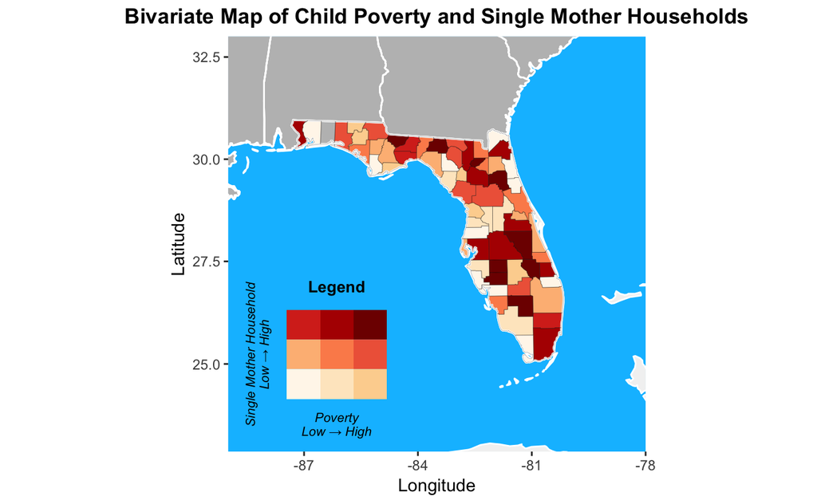